⚠️ This project is mandatory for certification bloc #2.

[figure not shown]

# Speed Dating with Tinder

## Company's description 📇

[Tinder](https://tinder.com/) is an online dating and geosocial networking application. In Tinder, users "swipe right" to like or "swipe left" to dislike other users' profiles, which include their photos, a short bio, and a list of their interests.

Tinder was launched by Sean Rad at a hackathon held at the Hatch Labs incubator in West Hollywood in 2012.

As of 2021, Tinder has recorded more than 65 billion matches worldwide.

## Project 🚧

The marketing team needs help on a new project. They are experiencing a decrease in the number of matches, and they are trying to find a way to understand **what makes people interested into each other**.

They decided to run a speed dating experiment with people who had to give Tinder lots of informations about themselves that could ultimately reflect on their dating profile on the app.

Tinder then gathered the data from this experiment. Each row in the dataset represents one speed date between two people, and indicates whether each of them secretly agreed to go on a second date with the other person.

## Goals 🎯

Use the dataset to understand what makes people interested in each other to go on a second date together:

- You may use descriptive statistics
- You may use visualisations

## Scope of this project 🖼️

Data was gathered from participants in experimental speed dating events from 2002-2004. During the events, the attendees would have a four minute "first date" with every other participant of the opposite sex. At the end of their four minutes, participants were asked if they would like to see their date again. They were also asked to rate their date on six attributes: Attractiveness, Sincerity, Intelligence, Fun, Ambition, and Shared Interests.

The dataset also includes questionnaire data gathered from participants at different points in the process. These fields include: demographics, dating habits, self-perception across key attributes, beliefs on what others find valuable in a mate, and lifestyle information.

[Dataset](https://full-stack-assets.s3.eu-west-3.amazonaws.com/M03-EDA/Speed+Dating+Data.csv)

[Dataset Description](https://full-stack-assets.s3.eu-west-3.amazonaws.com/M03-EDA/Speed+Dating+Data+Key.doc)

## Helpers 🦮

Data Exploration Ideas :

- **Q1** — What are the least desirable attributes in a male partner? Does this differ for female partners?
- **Q2** — How important do people think attractiveness is in potential mate selection vs. its real impact?
- **Q3** — Are shared interests more important than a shared racial background?
- **Q4** — Can people accurately predict their own perceived value in the dating market?
- **Q5** — In terms of getting a second date, is it better to be someone's first speed date of the night or their last?

## Deliverable 📬

To complete this project, your team should deliver a notebook with:

- descriptive statistics
- visualisations
- captions and interpretations on how the stats and visualisations are relevant to why people agree to a second date

## 1. Présentation du Projet

Ce projet analyse les données collectées lors d'expériences de speed dating (2002-2004) pour identifier les facteurs qui influencent la décision d'obtenir un second rendez-vous. Nous répondrons aux **5 questions clés** posées par le sujet, en nous appuyant sur des statistiques descriptives et des visualisations.

## 2. Importation des Bibliothèques

```python
# Importation des bibliothèques :
# - pandas     : manipulation et analyse des données (DataFrame)
# - numpy      : calculs numériques (angles du radar chart)
# - seaborn    : visualisations statistiques avancées
# - matplotlib : création et personnalisation des graphiques
import pandas as pd
import numpy as np
import seaborn as sns
import matplotlib.pyplot as plt

# Affichage des graphiques directement dans le notebook
%matplotlib inline
```

## 3. Chargement et Exploration Initiale

```python
# Chargement du fichier CSV
# Note : le paramètre encoding='ISO-8859-1' (Latin-1) est nécessaire pour lire
# correctement les caractères spéciaux (accents, etc.) présents dans ce dataset
df = pd.read_csv('data/Speed+Dating+Data.csv', encoding='ISO-8859-1')

# Affichage des dimensions du dataset (nombre de Lignes et de Colonnes)
print(f"Le Dataset contient {df.shape[0]} lignes et {df.shape[1]} colonnes.")

# Aperçu des 5 premières lignes pour visualiser la structure des données
df.head()
```

```
Le Dataset contient 8378 lignes et 195 colonnes.
```

|  | iid | id | gender | idg | condtn | wave | round | position | positin1 | order | ... | attr3_3 | sinc3_3 | intel3_3 | fun3_3 | amb3_3 | attr5_3 | sinc5_3 | intel5_3 | fun5_3 | amb5_3 |
| --- | --- | --- | --- | --- | --- | --- | --- | --- | --- | --- | --- | --- | --- | --- | --- | --- | --- | --- | --- | --- | --- |
| 0 | 1 | 1.0 | 0 | 1 | 1 | 1 | 10 | 7 | NaN | 4 | ... | 5.0 | 7.0 | 7.0 | 7.0 | 7.0 | NaN | NaN | NaN | NaN | NaN |
| 1 | 1 | 1.0 | 0 | 1 | 1 | 1 | 10 | 7 | NaN | 3 | ... | 5.0 | 7.0 | 7.0 | 7.0 | 7.0 | NaN | NaN | NaN | NaN | NaN |
| 2 | 1 | 1.0 | 0 | 1 | 1 | 1 | 10 | 7 | NaN | 10 | ... | 5.0 | 7.0 | 7.0 | 7.0 | 7.0 | NaN | NaN | NaN | NaN | NaN |
| 3 | 1 | 1.0 | 0 | 1 | 1 | 1 | 10 | 7 | NaN | 5 | ... | 5.0 | 7.0 | 7.0 | 7.0 | 7.0 | NaN | NaN | NaN | NaN | NaN |
| 4 | 1 | 1.0 | 0 | 1 | 1 | 1 | 10 | 7 | NaN | 7 | ... | 5.0 | 7.0 | 7.0 | 7.0 | 7.0 | NaN | NaN | NaN | NaN | NaN |

5 rows × 195 columns

## 4. Nettoyage des Données (Data Cleaning)

Le dataset original est très large (195 colonnes). On procède en trois étapes :

1. **Sélection des colonnes utiles** pour nos analyses
2. **Suppression des lignes incomplètes** avec `dropna()` — la quantité de données restante reste suffisante
3. **Renommage du genre** pour améliorer la lisibilité des graphiques

```python
# Colonnes de scores : notes attribuées par le partenaire (suffixe _o = "other", i.e. l'autre personne)
score_cols = ['attr_o', 'sinc_o', 'intel_o', 'fun_o', 'amb_o', 'shar_o']

# Colonnes contextuelles : variables démographiques et résultats
# iid      : identifiant unique du participant qui note
# gender   : genre du participant (0=Femme, 1=Homme)
# match    : 1 si les deux personnes ont dit Oui, 0 sinon
# dec_o    : décision de l'autre personne (1=Oui, 0=Non)
# int_corr : corrélation des intérêts entre les deux partenaires
# order    : numéro de passage du rendez-vous dans la soirée
# age      : âge du participant
# samerace : 1 si les deux partenaires sont de la même race
context_cols = ['iid', 'gender', 'match', 'dec_o', 'int_corr', 'order', 'age', 'samerace']

# Vérification de l'absence de doublons dans le dataset d'origine
print(f"Nombre de lignes en double : {df.duplicated().sum()}")

# Création du DataFrame nettoyé : sélection des colonnes puis suppression des lignes incomplètes
df_clean = df[context_cols + score_cols].dropna().copy()

# Transformation de la variable 'gender' (0/1) en libellés explicites
df_clean['gender'] = df_clean['gender'].apply(lambda x: 'Femme' if x == 0 else 'Homme')

# Vérification finale
print(f"Nombre de valeurs manquantes après nettoyage : {df_clean.isnull().sum().sum()}")
print(f"Taille du DataFrame nettoyé : {df_clean.shape[0]} lignes, {df_clean.shape[1]} colonnes.")
df_clean.head()
```

```
Nombre de lignes en double : 0
Nombre de valeurs manquantes après nettoyage : 0
Taille du DataFrame nettoyé : 6875 lignes, 14 colonnes.
```

|  | iid | gender | match | dec_o | int_corr | order | age | samerace | attr_o | sinc_o | intel_o | fun_o | amb_o | shar_o |
| --- | --- | --- | --- | --- | --- | --- | --- | --- | --- | --- | --- | --- | --- | --- |
| 0 | 1 | Femme | 0 | 0 | 0.14 | 4 | 21.0 | 0 | 6.0 | 8.0 | 8.0 | 8.0 | 8.0 | 6.0 |
| 1 | 1 | Femme | 0 | 0 | 0.54 | 3 | 21.0 | 0 | 7.0 | 8.0 | 10.0 | 7.0 | 7.0 | 5.0 |
| 2 | 1 | Femme | 1 | 1 | 0.16 | 10 | 21.0 | 1 | 10.0 | 10.0 | 10.0 | 10.0 | 10.0 | 10.0 |
| 3 | 1 | Femme | 1 | 1 | 0.61 | 5 | 21.0 | 0 | 7.0 | 8.0 | 9.0 | 8.0 | 9.0 | 8.0 |
| 4 | 1 | Femme | 1 | 1 | 0.21 | 7 | 21.0 | 0 | 8.0 | 7.0 | 9.0 | 6.0 | 9.0 | 7.0 |

## 5. Statistiques Descriptives Générales

```python
# Statistiques descriptives sur les 6 critères de notation
# (count, mean, std, min, quartiles, max)
print("Statistiques des notes reçues par les participants :")
display(df_clean[score_cols].describe().round(2))
```

```
Statistiques des notes reçues par les participants :
```

|  | attr_o | sinc_o | intel_o | fun_o | amb_o | shar_o |
| --- | --- | --- | --- | --- | --- | --- |
| count | 6875.00 | 6875.00 | 6875.00 | 6875.00 | 6875.00 | 6875.00 |
| mean | 6.18 | 7.16 | 7.36 | 6.40 | 6.76 | 5.46 |
| std | 1.95 | 1.75 | 1.56 | 1.96 | 1.80 | 2.15 |
| min | 0.00 | 0.00 | 0.00 | 0.00 | 0.00 | 0.00 |
| 25% | 5.00 | 6.00 | 6.00 | 5.00 | 6.00 | 4.00 |
| 50% | 6.00 | 7.00 | 7.00 | 7.00 | 7.00 | 6.00 |
| 75% | 8.00 | 8.00 | 8.00 | 8.00 | 8.00 | 7.00 |
| max | 10.00 | 10.00 | 10.00 | 11.00 | 10.00 | 10.00 |

```python
# Analyse des biais de notation : certains participants notent-ils de façon constante ?
# On groupe par 'iid' et on calcule l'écart-type des notes d'attractivité données.
# Un écart-type = 0 signifie que le participant donne toujours la même note : biais de réponse.
voters_std    = df.groupby('iid')['attr'].std()
extreme_voters = voters_std[voters_std == 0]

print(f"Nombre de participants avec une notation constante (écart-type = 0) : {len(extreme_voters)}")
print(f"Soit {len(extreme_voters)/len(voters_std)*100:.1f}% des participants — biais marginal sur nos analyses.")

if len(extreme_voters) > 0:
    print("\nNote moyenne (constante) attribuée par ces participants :")
    print(df[df['iid'].isin(extreme_voters.index)].groupby('iid')['attr'].mean())
```

```
Nombre de participants avec une notation constante (écart-type = 0) : 3
Soit 0.5% des participants — biais marginal sur nos analyses.

Note moyenne (constante) attribuée par ces participants :
iid
13     10.0
98     10.0
415     5.0
Name: attr, dtype: float64
```

**Interprétation :** Ces participants présentent un **biais de réponse** (notation sans discrimination). Leur part étant marginale, ils n'invalident pas nos analyses mais constituent un signal de qualité à garder en tête.

## 6. Analyse de la Variable Cible : Le Match

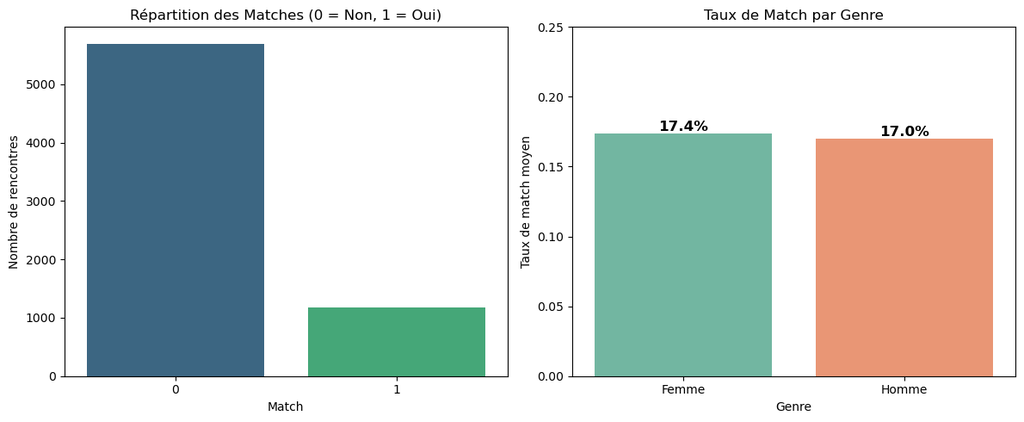

```python
# Répartition globale des matches
fig, axes = plt.subplots(1, 2, figsize=(12, 5))

# Graphique 1 : Countplot de la distribution des matches
sns.countplot(x='match', data=df_clean, hue='match', palette='viridis',
              legend=False, ax=axes[0])
axes[0].set_title("Répartition des Matches (0 = Non, 1 = Oui)")
axes[0].set_xlabel("Match")
axes[0].set_ylabel("Nombre de rencontres")

# Graphique 2 : Taux de match par genre
match_by_gender = df_clean.groupby('gender')['match'].mean().reset_index()
sns.barplot(x='gender', y='match', data=match_by_gender, hue='gender', legend=False, palette='Set2', ax=axes[1])
axes[1].set_title("Taux de Match par Genre")
axes[1].set_xlabel("Genre")
axes[1].set_ylabel("Taux de match moyen")
axes[1].set_ylim(0, 0.25)

# Annotation des valeurs
for p in axes[1].patches:
    axes[1].annotate(f'{p.get_height():.1%}',
                     (p.get_x() + p.get_width() / 2., p.get_height()),
                     ha='center', va='bottom', fontsize=12, fontweight='bold')

plt.tight_layout()
plt.show()
```

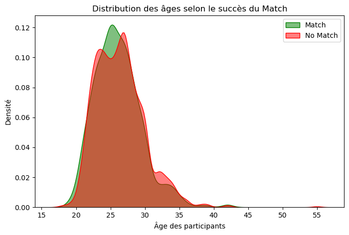

```python
# Distribution des âges selon le résultat du match
# Un KDE (Kernel Density Estimate) montre la distribution continue de l'âge
# pour les matchés vs. non-matchés
plt.figure(figsize=(8, 5))

sns.kdeplot(df_clean[df_clean['match'] == 1]['age'],
            label='Match', fill=True, color='green', alpha=0.5)
sns.kdeplot(df_clean[df_clean['match'] == 0]['age'],
            label='No Match', fill=True, color='red', alpha=0.5)

plt.title("Distribution des âges selon le succès du Match")
plt.xlabel("Âge des participants")
plt.ylabel("Densité")
plt.legend()
plt.show()
```

**Interprétation :** Les deux courbes se superposent quasi parfaitement : **l'âge n'est pas un facteur discriminant** pour le succès en speed dating. La majorité des participants a entre 22 et 28 ans, et les chances de match sont réparties uniformément à travers cette tranche.

## 7. Impact de l'Attractivité Physique sur le Match

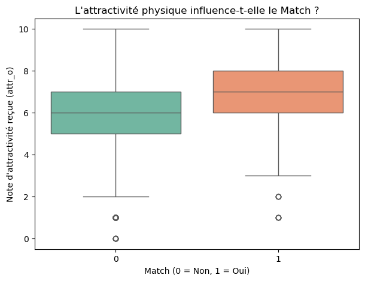

```python
# Boxplot : distribution des notes d'attractivité reçues selon le résultat
# Cela permet de voir si être bien noté sur l'attractivité conditionne le match
plt.figure(figsize=(7, 5))
sns.boxplot(x='match', y='attr_o', data=df_clean, hue='match', legend=False, palette='Set2')
plt.title("L'attractivité physique influence-t-elle le Match ?")
plt.xlabel("Match (0 = Non, 1 = Oui)")
plt.ylabel("Note d'attractivité reçue (attr_o)")
plt.show()
```

## 8. Q1 - Quels sont les attributs les moins désirables selon le genre ?

> *"Quels sont les traits les moins souhaitables (valorisants) chez un partenaire masculin ? Cela diffère-t-il pour les partenaires féminines ?"*

Le dataset contient des colonnes `pf_o_*` ("partner's preferences about the opposite sex") : ce que chaque participant **pense** que le sexe opposé valorise, réparti sur 100 points.

```
Ce que chaque genre pense que le sexe opposé valorise (sur 100 points) :
```

|  | Attractivité | Sincérité | Intelligence | Humour | Ambition | Intérêts |
| --- | --- | --- | --- | --- | --- | --- |
| Femmes | 26.9 | 16.5 | 19.5 | 17.8 | 8.6 | 11.0 |
| Hommes | 18.1 | 18.3 | 21.0 | 17.1 | 12.8 | 12.7 |

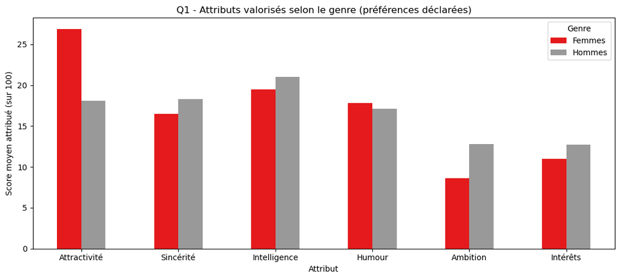

```python
# Colonnes des préférences déclarées sur ce que le sexe opposé valorise
# pf_o_att = attractivité, pf_o_sin = sincérité, pf_o_int = intelligence
# pf_o_fun = humour, pf_o_amb = ambition, pf_o_sha = intérêts partagés
# Ces scores sont répartis sur 100 (somme = 100 par participant)
pf_cols      = ['pf_o_att', 'pf_o_sin', 'pf_o_int', 'pf_o_fun', 'pf_o_amb', 'pf_o_sha']
pf_labels    = ['Attractivité', 'Sincérité', 'Intelligence', 'Humour', 'Ambition', 'Intérêts']

# Calcul des moyennes par genre (gender=0 Femme, gender=1 Homme dans df d'origine)
pf_df = df.groupby('gender')[pf_cols].mean().round(1)
pf_df.index = ['Femmes', 'Hommes']
pf_df.columns = pf_labels

# Affichage du tableau récapitulatif
print("Ce que chaque genre pense que le sexe opposé valorise (sur 100 points) :")
display(pf_df)

# Visualisation : graphique en barres groupées
pf_df.T.plot(kind='bar', figsize=(11, 5), colormap='Set1')
plt.title("Q1 - Attributs valorisés selon le genre (préférences déclarées)")
plt.ylabel("Score moyen attribué (sur 100)")
plt.xlabel("Attribut")
plt.xticks(rotation=0)
plt.legend(title='Genre')
plt.tight_layout()
plt.show()
```

**Réponse à Q1 :**

Les différences notables selon le genre :

- Les **femmes** pensent que les hommes valorisent avant tout **l'Attractivité physique** (26.9 pts) - bien au-dessus de tous les autres critères.
- Les **hommes** pensent que les femmes valorisent surtout **l'Intelligence** (21.0 pts) et la **Sincérité** (18.3 pts), avec une Attractivité perçue comme moins prioritaire (18.1 pts).

**Conclusion :** Les femmes ont une vision stéréotypée de la superficialité masculine, tandis que les hommes surestiment l'importance que les femmes accordent à l'intelligence. Ces biais de perception seront confrontés aux données réelles en Q2.

## 9. Q2 - Importance perçue de l'attractivité vs. impact réel

> *"Quelle importance les gens accordent-ils à l’attractivité dans la sélection des partenaires potentiels par rapport à son impact réel ?"*

On compare ici ce que les participants **déclarent** valoriser (`attr1_1`) avec ce qui **influence réellement** leur décision (`dec_o`).

```
Importance déclarée vs. Impact réel sur la décision :
```

|  | Importance déclarée (sur 100) | Impact réel (corrélation × 100) |
| --- | --- | --- |
| Attractivité | 22.5 | 48.8 |
| Sincérité | 17.4 | 20.8 |
| Intelligence | 20.3 | 21.4 |
| Humour | 17.5 | 41.2 |
| Ambition | 10.7 | 18.3 |
| Intérêts | 11.8 | 39.8 |

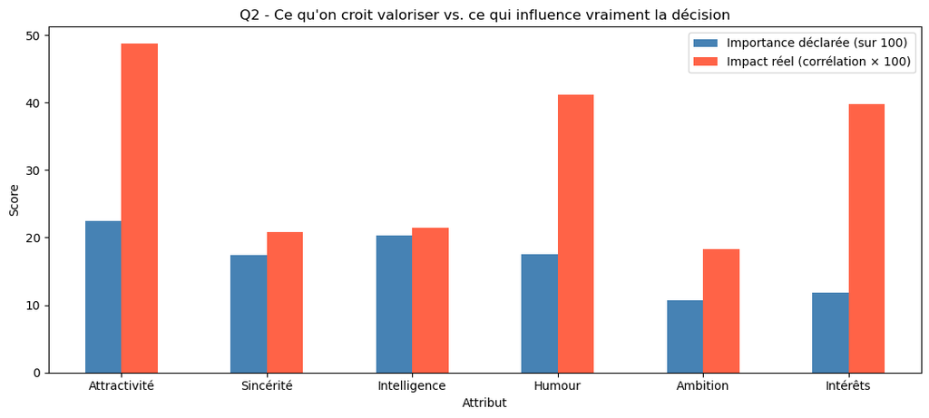

```python
# attr1_1, sinc1_1, etc. = importance déclarée par le participant pour chaque attribut
# Ces scores sont répartis sur 100 points (somme = 100 par participant)
imp_cols   = ['attr1_1', 'sinc1_1', 'intel1_1', 'fun1_1', 'amb1_1', 'shar1_1']
imp_labels = ['Attractivité', 'Sincérité', 'Intelligence', 'Humour', 'Ambition', 'Intérêts']

# Importance déclarée : moyenne pour tous les participants
importance_declaree = df[imp_cols].mean().round(1).values

# Impact réel : corrélation de chaque note reçue avec la décision finale (dec_o)
# On multiplie par 100 pour avoir des valeurs comparables visuellement
impact_reel = (df_clean[score_cols + ['dec_o']].corr()['dec_o']
               .drop('dec_o') * 100).round(1).values

# Création du DataFrame comparatif
comparatif = pd.DataFrame({
    'Importance déclarée (sur 100)': importance_declaree,
    'Impact réel (corrélation × 100)': impact_reel
}, index=imp_labels)

print("Importance déclarée vs. Impact réel sur la décision :")
display(comparatif.round(1))

# Visualisation : double barplot côte à côte
comparatif.plot(kind='bar', figsize=(11, 5), color=['steelblue', 'tomato'])
plt.title("Q2 - Ce qu'on croit valoriser vs. ce qui influence vraiment la décision")
plt.ylabel("Score")
plt.xlabel("Attribut")
plt.xticks(rotation=0)
plt.legend()
plt.tight_layout()
plt.show()
```

**Réponse à Q2 :**

**Conclusion :** Les participants rationalisent leurs choix en mettant en avant des valeurs "nobles" (sincérité, intelligence), mais décident en réalité d'abord avec leurs yeux. Ce biais de désirabilité sociale est classique en psychologie comportementale.

## 10. Q3 - Intérêts communs vs. même origine raciale

> *"Les intérêts communs sont-ils plus importants qu’une origine raciale commune ?"*

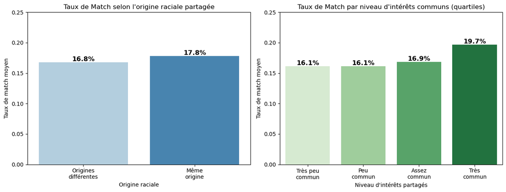

```python
# Comparaison du taux de match selon :
# - samerace  : 1 si les deux partenaires sont de la même origine raciale
# - int_corr  : score de corrélation des intérêts entre les deux partenaires

fig, axes = plt.subplots(1, 2, figsize=(13, 5))

# --- Graphique 1 : Taux de match selon samerace ---
race_match = df_clean.groupby('samerace')['match'].mean().reset_index()
race_match['samerace'] = race_match['samerace'].map({0: 'Origines\ndifférentes', 1: 'Même\norigine'})
sns.barplot(x='samerace', y='match', data=race_match, hue='samerace', legend=False, palette='Blues', ax=axes[0])
axes[0].set_title("Taux de Match selon l'origine raciale partagée")
axes[0].set_xlabel("Origine raciale")
axes[0].set_ylabel("Taux de match moyen")
axes[0].set_ylim(0, 0.25)
for p in axes[0].patches:
    axes[0].annotate(f'{p.get_height():.1%}',
                     (p.get_x() + p.get_width() / 2., p.get_height()),
                     ha='center', va='bottom', fontsize=12, fontweight='bold')

# --- Graphique 2 : Taux de match par quartile d'intérêts communs ---
# On découpe int_corr en 4 quartiles pour visualiser l'effet progressif
df_clean_q = df_clean.copy()
df_clean_q['int_corr_q'] = pd.qcut(df_clean_q['int_corr'], q=4,
                                     labels=['Très peu\ncommun', 'Peu\ncommun',
                                             'Assez\ncommun', 'Très\ncommun'])
int_match = df_clean_q.groupby('int_corr_q', observed=True)['match'].mean().reset_index()
sns.barplot(x='int_corr_q', y='match', data=int_match, hue='int_corr_q', legend=False, palette='Greens', ax=axes[1])
axes[1].set_title("Taux de Match par niveau d'intérêts communs (quartiles)")
axes[1].set_xlabel("Niveau d'intérêts partagés")
axes[1].set_ylabel("Taux de match moyen")
axes[1].set_ylim(0, 0.25)
for p in axes[1].patches:
    axes[1].annotate(f'{p.get_height():.1%}',
                     (p.get_x() + p.get_width() / 2., p.get_height()),
                     ha='center', va='bottom', fontsize=12, fontweight='bold')

plt.tight_layout()
plt.show()
```

**Réponse à Q3 :**

[output not shown]

**Conclusion : Les intérêts communs ont un impact 3× plus fort que l'origine raciale partagée.** L'origine raciale joue un rôle très marginal (+1 point seulement), tandis que la corrélation des centres d'intérêt améliore significativement les chances de match. Ce résultat est encourageant : il suggère que les algorithmes de matching basés sur les passions sont plus efficaces que la proximité démographique.

## 11. Q4 - Les gens peuvent-ils prédire leur valeur perçue sur le marché ?

> *"Les gens peuvent-ils prédire avec précision leur propre valeur perçue sur le marché des rencontres ?"*

On compare ici `attr3_1` (comment le participant **pense** être perçu par les autres) avec `attr_o` (comment il est **réellement** noté par ses partenaires).

```
Auto-perception vs. note réellement reçue (sur 10) :
```

| Attribut | Auto-perception | Note réelle reçue | Surestimation |
| --- | --- | --- | --- |
| Attractivité | 7.08 | 6.18 | 0.90 |
| Sincérité | 8.30 | 7.18 | 1.13 |
| Intelligence | 8.41 | 7.36 | 1.04 |

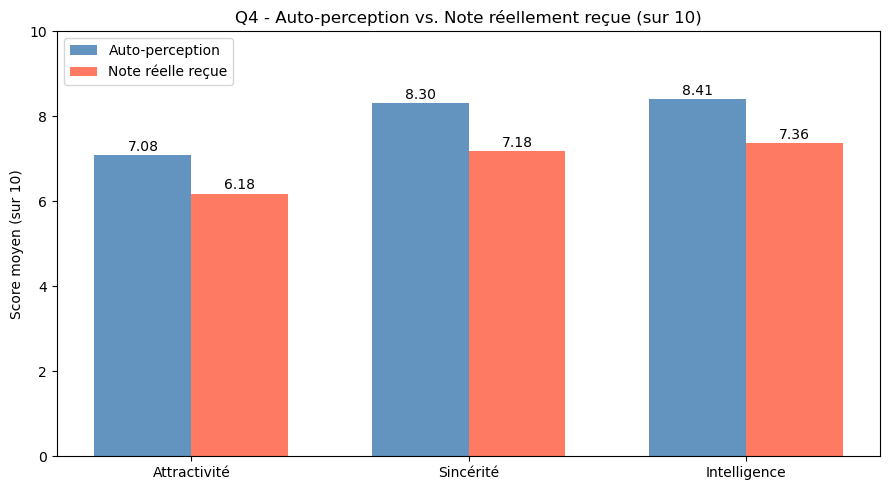

```
Corrélation auto-perception / note réelle (attractivité) : 0.175
```

```python
# attr3_1  = auto-évaluation : comment le participant pense que les autres le perçoivent
# sinc3_1  = idem pour la sincérité
# intel3_1 = idem pour l'intelligence
# attr_o, sinc_o, intel_o = notes réellement reçues de ses partenaires

# Création d'un DataFrame dédié avec seulement les colonnes nécessaires
q4_cols = ['attr3_1', 'attr_o', 'sinc3_1', 'sinc_o', 'intel3_1', 'intel_o']
q4_df   = df[q4_cols].dropna()

# Calcul des moyennes perçues vs. réelles
comparatif_q4 = pd.DataFrame({
    'Attribut'         : ['Attractivité', 'Sincérité', 'Intelligence'],
    'Auto-perception'  : [q4_df['attr3_1'].mean(), q4_df['sinc3_1'].mean(), q4_df['intel3_1'].mean()],
    'Note réelle reçue': [q4_df['attr_o'].mean(),  q4_df['sinc_o'].mean(),  q4_df['intel_o'].mean()]
})
comparatif_q4['Surestimation'] = (comparatif_q4['Auto-perception'] -
                                   comparatif_q4['Note réelle reçue']).round(2)

print("Auto-perception vs. note réellement reçue (sur 10) :")
display(comparatif_q4.set_index('Attribut').round(2))

# Visualisation : graphique comparatif
x = np.arange(3)
width = 0.35
fig, ax = plt.subplots(figsize=(9, 5))

bars1 = ax.bar(x - width/2, comparatif_q4['Auto-perception'],   width, label='Auto-perception',   color='steelblue', alpha=0.85)
bars2 = ax.bar(x + width/2, comparatif_q4['Note réelle reçue'], width, label='Note réelle reçue', color='tomato',     alpha=0.85)

# Annotation des barres
for bar in bars1:
    ax.annotate(f'{bar.get_height():.2f}',
                xy=(bar.get_x() + bar.get_width() / 2, bar.get_height()),
                xytext=(0, 3), textcoords='offset points', ha='center', fontsize=10)
for bar in bars2:
    ax.annotate(f'{bar.get_height():.2f}',
                xy=(bar.get_x() + bar.get_width() / 2, bar.get_height()),
                xytext=(0, 3), textcoords='offset points', ha='center', fontsize=10)

ax.set_title("Q4 - Auto-perception vs. Note réellement reçue (sur 10)")
ax.set_xticks(x)
ax.set_xticklabels(['Attractivité', 'Sincérité', 'Intelligence'])
ax.set_ylabel("Score moyen (sur 10)")
ax.set_ylim(0, 10)
ax.legend()
plt.tight_layout()
plt.show()

# Corrélation entre auto-perception et note réelle
print(f"\nCorrélation auto-perception / note réelle (attractivité) : "
      f"{q4_df['attr3_1'].corr(q4_df['attr_o']):.3f}")
```

**Réponse à Q4 :**

**Non, les gens ne peuvent pas prédire précisément leur valeur perçue.** On observe une **surestimation systématique et significative** sur les trois attributs :

- Attractivité : surestimée de **+0.90 point** (7.08 perçu vs 6.18 réel)
- Sincérité : surestimée de **+1.13 point** (8.30 vs 7.18)
- Intelligence : surestimée de **+1.04 point** (8.41 vs 7.36)

La corrélation entre auto-perception et note réelle d'attractivité n'est que de **0.175** - très faible. Les gens ont donc une vision très imprécise de leur attractivité réelle. Ce phénomène s'appelle le **biais d'auto-complaisance** (*self-serving bias*) : on a naturellement tendance à se percevoir plus positivement que les autres ne nous voient.

## 12. Q5 - Mieux vaut-il être le premier ou le dernier rendez-vous de la soirée ?

> *"Pour obtenir un deuxième rendez-vous, est-il préférable d’être le premier speed date de la soirée ou le dernier ?"*

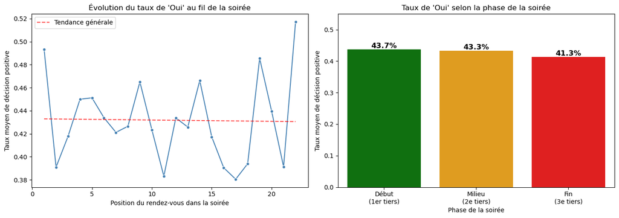

```
Taux de 'Oui' pour les 3 premiers rendez-vous : 43.4%
Taux de 'Oui' pour les 3 derniers rendez-vous  : 43.5%
Écart en faveur du début de soirée : -0.0 points
```

```python
# 'order' = position du rendez-vous dans la soirée (1 = premier, max ≈ 22 = dernier)
# On calcule le taux moyen de décision positive (dec_o) pour chaque position

fig, axes = plt.subplots(1, 2, figsize=(14, 5))

# --- Graphique 1 : Évolution du taux de 'Oui' position par position ---
order_rate = df_clean.groupby('order')['dec_o'].mean().reset_index()
sns.lineplot(x='order', y='dec_o', data=order_rate, color='steelblue', marker='o',
             markersize=5, ax=axes[0])
axes[0].set_title("Évolution du taux de 'Oui' au fil de la soirée")
axes[0].set_xlabel("Position du rendez-vous dans la soirée")
axes[0].set_ylabel("Taux moyen de décision positive")

# Ligne de tendance pour mieux visualiser la direction générale
z = np.polyfit(order_rate['order'], order_rate['dec_o'], 1)
p = np.poly1d(z)
axes[0].plot(order_rate['order'], p(order_rate['order']),
             "r--", alpha=0.7, label='Tendance générale')
axes[0].legend()

# --- Graphique 2 : Comparaison 1er tiers vs. dernier tiers ---
# On découpe la soirée en 3 phases : début, milieu, fin
max_order = df_clean['order'].max()
df_clean_phase = df_clean.copy()
df_clean_phase['phase'] = pd.cut(
    df_clean_phase['order'],
    bins=[0, max_order * 0.33, max_order * 0.66, max_order],
    labels=['Début\n(1er tiers)', 'Milieu\n(2e tiers)', 'Fin\n(3e tiers)']
)

phase_rate = df_clean_phase.groupby('phase', observed=True)['dec_o'].mean().reset_index()
sns.barplot(x='phase', y='dec_o', data=phase_rate,
            hue='phase', legend=False, palette=['green', 'orange', 'red'], ax=axes[1])
axes[1].set_title("Taux de 'Oui' selon la phase de la soirée")
axes[1].set_xlabel("Phase de la soirée")
axes[1].set_ylabel("Taux moyen de décision positive")
axes[1].set_ylim(0, 0.55)
for p_bar in axes[1].patches:
    axes[1].annotate(f'{p_bar.get_height():.1%}',
                     (p_bar.get_x() + p_bar.get_width() / 2., p_bar.get_height()),
                     ha='center', va='bottom', fontsize=12, fontweight='bold')

plt.tight_layout()
plt.show()

# Statistiques clés
first_3 = df_clean[df_clean['order'] <= 3]['dec_o'].mean()
last_3  = df_clean[df_clean['order'] >= df_clean['order'].max() - 2]['dec_o'].mean()
print(f"Taux de 'Oui' pour les 3 premiers rendez-vous : {first_3:.1%}")
print(f"Taux de 'Oui' pour les 3 derniers rendez-vous  : {last_3:.1%}")
print(f"Écart en faveur du début de soirée : {(first_3 - last_3)*100:.1f} points")
```

**Réponse à Q5 :**

## 13. Analyse Approfondie : Profils par Genre et Corrélations

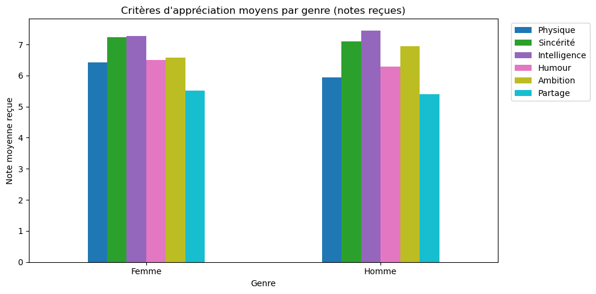

```python
# Comparaison des notes moyennes reçues par genre
gender_analysis = df_clean.groupby('gender')[score_cols].mean()

gender_analysis.plot(kind='bar', figsize=(10, 5), colormap='tab10')
plt.title("Critères d'appréciation moyens par genre (notes reçues)")
plt.ylabel("Note moyenne reçue")
plt.xlabel("Genre")
plt.xticks(rotation=0)
plt.legend(
    labels=['Physique', 'Sincérité', 'Intelligence', 'Humour', 'Ambition', 'Partage'],
    bbox_to_anchor=(1.02, 1), loc='upper left'
)
plt.tight_layout()
plt.show()
```

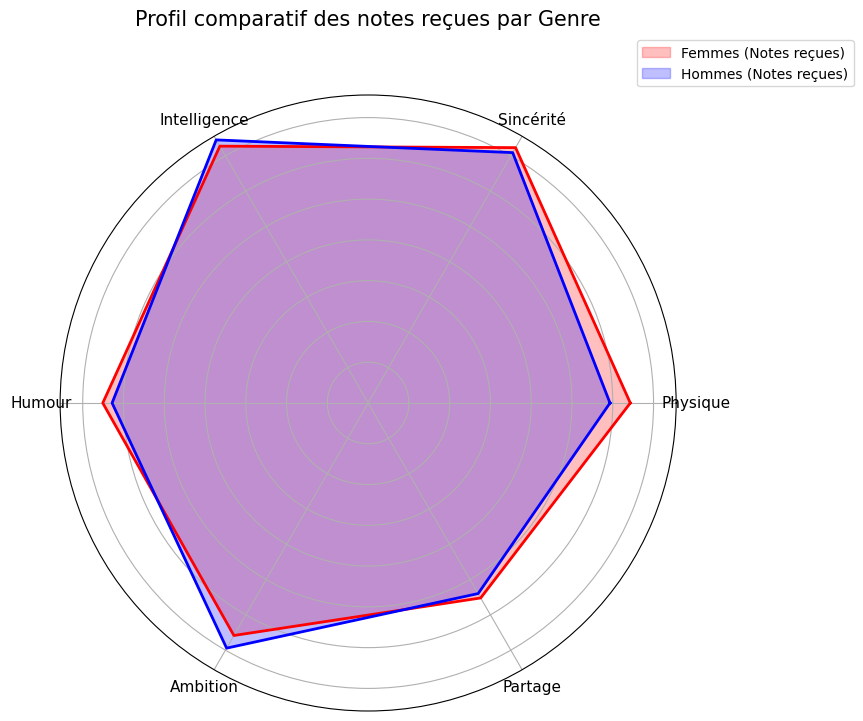

```python
# Graphique Radar : profil comparatif des notes reçues par genre
labels       = np.array(['Physique', 'Sincérité', 'Intelligence', 'Humour', 'Ambition', 'Partage'])
stats_femmes = df_clean[df_clean['gender'] == 'Femme'][score_cols].mean().values
stats_hommes = df_clean[df_clean['gender'] == 'Homme'][score_cols].mean().values

# Fermeture de la boucle du radar (répéter le premier point pour fermer le polygone)
stats_femmes = np.concatenate((stats_femmes, [stats_femmes[0]]))
stats_hommes = np.concatenate((stats_hommes, [stats_hommes[0]]))
angles       = np.linspace(0, 2 * np.pi, len(labels), endpoint=False).tolist()
angles      += angles[:1]

fig, ax = plt.subplots(figsize=(8, 8), subplot_kw=dict(polar=True))

ax.fill(angles, stats_femmes, color='red',  alpha=0.25, label='Femmes (Notes reçues)')
ax.plot(angles, stats_femmes, color='red',  linewidth=2)
ax.fill(angles, stats_hommes, color='blue', alpha=0.25, label='Hommes (Notes reçues)')
ax.plot(angles, stats_hommes, color='blue', linewidth=2)

ax.set_yticklabels([])
ax.set_xticks(angles[:-1])
ax.set_xticklabels(labels, fontsize=11)

plt.title("Profil comparatif des notes reçues par Genre", size=15, y=1.1)
plt.legend(loc='upper right', bbox_to_anchor=(1.3, 1.1))
plt.show()
```

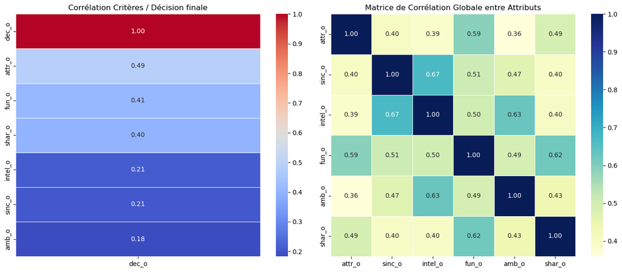

```python
# Heatmap de corrélation : chaque critère vs. la décision finale
fig, axes = plt.subplots(1, 2, figsize=(14, 6))

# --- Heatmap 1 : Corrélation critères → décision finale ---
correlation = (df_clean[score_cols + ['dec_o']]
               .corr()[['dec_o']]
               .sort_values(by='dec_o', ascending=False))
sns.heatmap(correlation, annot=True, cmap='coolwarm', fmt='.2f',
            linewidths=0.5, ax=axes[0])
axes[0].set_title("Corrélation Critères / Décision finale")

# --- Heatmap 2 : Matrice de corrélation globale entre attributs ---
corr_globale = df_clean[score_cols].corr()
sns.heatmap(corr_globale, annot=True, cmap='YlGnBu', fmt='.2f',
            linewidths=0.5, ax=axes[1])
axes[1].set_title("Matrice de Corrélation Globale entre Attributs")

plt.tight_layout()
plt.show()
```

**Interprétation :**

- **Heatmap gauche** : L'attractivité (`attr_o`, corr = 0.49) est le critère le plus corrélé à la décision finale, suivi de l'humour (0.41) et des intérêts partagés (0.40). La sincérité et l'ambition sont les moins influents (≈ 0.18-0.21).
- **Heatmap droite** : On observe un **effet de halo** entre l'attractivité et les autres traits - être jugé physiquement attirant booste inconsciemment les notes de personnalité. La forte corrélation entre `fun_o` et `shar_o` confirme que l'on s'amuse avec ceux qui nous ressemblent.

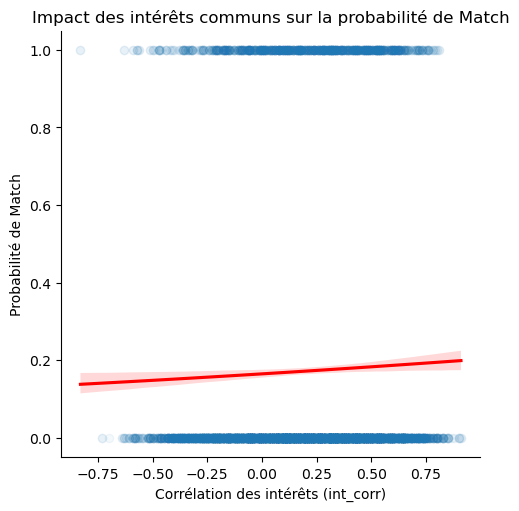

```python
# Régression logistique : probabilité de match selon la corrélation des intérêts
# La régression logistique est adaptée car la variable cible (match) est binaire (0/1)
sns.lmplot(x='int_corr', y='match', data=df_clean,
           logistic=True, scatter_kws={'alpha': 0.05}, line_kws={'color': 'red'})
plt.title("Impact des intérêts communs sur la probabilité de Match")
plt.xlabel("Corrélation des intérêts (int_corr)")
plt.ylabel("Probabilité de Match")
plt.show()
```

**Interprétation :** La courbe logistique ascendante confirme que **plus les intérêts sont partagés, plus la probabilité de match augmente** - un facteur de réussite plus stable et plus durable que l'attractivité physique, et donc plus actionnable par un algorithme de matching.

## 14. Conclusion Générale et Recommandations Stratégiques

L'analyse complète de ce dataset permet de répondre aux 5 questions du sujet et de formuler des recommandations concrètes pour Tinder.

### Synthèse des réponses aux 5 questions

[output not shown]

### Recommandations stratégiques pour Tinder

**1. Valoriser le contenu visuel des profils**  
L'attractivité est le premier filtre de sélection (corr = 0.49 avec la décision). Tinder devrait continuer à mettre les photos au cœur de l'expérience et proposer des outils d'aide à la sélection de la meilleure photo.

**2. Renforcer l'algorithme de matching par les passions**  
Les intérêts communs ont un impact 3× plus fort que l'origine raciale. L'ajout systématique de « Tags » de centres d'intérêt et leur pondération dans l'algorithme permettrait d'améliorer significativement le taux de match.